# Capsule 5 - Exploration univariée

MQT-2101 - Analyse et modélisation des données

## Pourquoi ça compte

Une décision concrète

Une seule moyenne peut-elle décrire fidèlement vos données?

« Environ 10 000 naissances par jour » : la moyenne paraît claire. Pourtant elle cache deux réalités, la semaine et le week-end. Décrire une variable seule, c’est apprendre à voir ce qu’un seul chiffre masque.

## Objectifs de la capsule

- Résumer une variable numérique avec quelques indicateurs simples.
- Distinguer ce que montrent la moyenne et la médiane.
- Construire un histogramme et écrire un constat prudent.

## La variable births

`births` est une variable numérique discrète : un nombre de naissances par journée.

| Question | Réponse |
| --- | --- |
| Que mesure-t-elle? | un nombre de naissances |
| Pour quelle unité? | une journée |
| Peut-on faire une moyenne? | oui, avec interprétation prudente |

## Résumer une variable numérique

min

plus petite valeur observée

méd.

valeur centrale robuste

max

plus grande valeur observée

« Robuste » signifie peu sensible aux valeurs extrêmes : c’est la force de la médiane.

## Minimum, moyenne, médiane, maximum

| Nombre de jours | Minimum | Moyenne | Médiane | Maximum |
| --- | --- | --- | --- | --- |
| 3652 | 6443 | 10876.8 | 11615 | 14540 |

Ces indicateurs décrivent la variable. Ils ne disent pas encore pourquoi les naissances varient d’un jour à l’autre.

## Moyenne et médiane

La moyenne utilise toutes les valeurs. La médiane coupe les observations en deux groupes de même taille.

Si elles sont proches, le centre paraît assez stable. Si elles sont très différentes, il faut regarder la distribution avant d’interpréter.

## Histogramme : voir la distribution

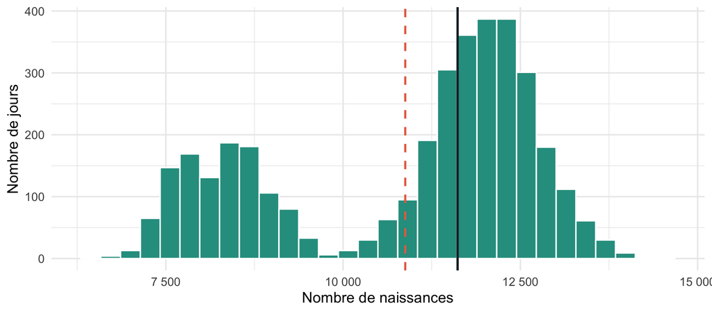

Trait plein : médiane. Trait tireté : moyenne. Modifier `bins` change le regard, pas les données.

## Deux bosses : la bimodalité

L’histogramme ne montre pas une seule cloche, mais deux paquets de valeurs.

Paquet haut

Paquet bas

Les week-ends : niveaux plus faibles, autour de 8 000.

La moyenne tombe « entre les deux » et ne décrit aucun des deux groupes. Pourquoi deux paquets? La capsule 6 le compare jour par jour.

## Écrire un constat prudent

Acceptable

`births` décrit un nombre quotidien de naissances ; ses valeurs forment deux groupes visibles dans l’histogramme.

À éviter

« Les naissances baissent le week-end à cause de… » : on décrit, on n’explique pas encore les causes.

## À retenir

1

Une analyse univariée décrit une variable à la fois.

2

Tableau et graphique se complètent ; moyenne et médiane ne suffisent pas seules.

3

Un constat descriptif ne devient pas une explication causale.

## Production autonome 1.5

Produisez une courte analyse univariée de `births`.

Un tableau (min, moyenne, médiane, max), un histogramme, une phrase descriptive prudente et une limite d’interprétation.

### Auto-vérification

- J’ai nommé l’unité d’observation et le type des variables.
- Mon graphique ou mon résumé répond exactement à la question.
- Ma conclusion contient une limite descriptive.